# Spatial Analysis with sf

## 10. Kriging: Interpolating Temperature Across Space

Monitoring stations tell us the temperature at specific points. But managers and policymakers often need continuous surfaces — temperature everywhere in a city, not just where we happened to put sensors. **Kriging** is the gold-standard geostatistical interpolation method for this task.

The key insight: stations that are close together tend to have similar temperatures (spatial autocorrelation). Kriging fits a model of that autocorrelation structure — the **variogram** — and uses it to make optimal predictions at unmeasured locations, along with prediction uncertainty (the kriging variance).

### 10.1 What is a variogram?

The **variogram** γ(h) quantifies how dissimilar pairs of observations are as a function of the distance h between them:

$$\gamma(h) = \frac{1}{2} \text{Var}[Z(s)
- Z(s + h)]$$

At short distances, nearby observations are similar so γ(h) is small. As h increases, observations become less correlated and γ(h) rises, eventually levelling off at the **sill** (total variance). The **range** is the distance beyond which observations are effectively uncorrelated. The **nugget** represents measurement error or fine-scale variation below the sampling resolution.

### 10.2 Fitting and plotting the variogram

```r
library(gstat)
library(sp)

# Work with a single city for a clean kriging example
la_stations <- stations |>
  filter(city == "Los Angeles") |>
  select(lon, lat, temp_C, imperv_frac, canopy_frac)

# Convert to sp SpatialPointsDataFrame (gstat uses sp internally)
coordinates(la_stations) <- ~ lon + lat
proj4string(la_stations)  <- CRS("+init=epsg:4326")

# Reproject to UTM zone 11N (metres) for meaningful distance units
la_utm <- spTransform(la_stations, CRS("+init=epsg:32611"))

# Compute empirical variogram
vario_emp <- variogram(temp_C ~ 1, data = la_utm, cutoff = 25000, width = 3000)

# Fit a spherical variogram model
vario_fit <- fit.variogram(vario_emp,
                            model = vgm(psill = 1.5, model = "Sph",
                                        range = 15000, nugget = 0.3))
print(vario_fit)
```

```
##   model    psill    range
## 1   Nug 0.000000     0.00
## 2   Sph 1.147199 14815.41
```

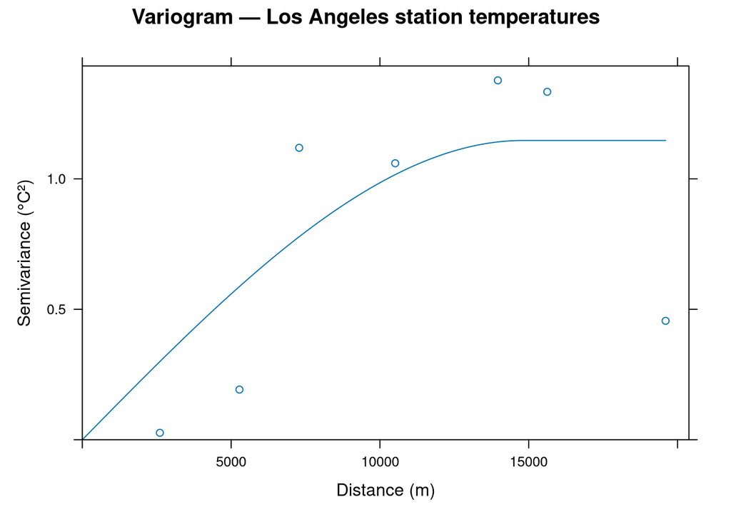

```r
# Plot
plot(vario_emp, vario_fit,
     main = "Variogram — Los Angeles station temperatures",
     xlab = "Distance (m)", ylab = "Semivariance (°C²)")
```

### 10.3 Building a prediction grid

```r
# Create a regular prediction grid over the LA bounding box
bb <- bbox(la_utm)
grid_pts <- expand.grid(
  lon = seq(bb[1,1], bb[1,2], length.out = 60),
  lat = seq(bb[2,1], bb[2,2], length.out = 60)
)

# Add covariate columns BEFORE converting to sp — assigning to a
# SpatialPixelsDataFrame after gridded() triggers a row-count mismatch error
grid_pts$imperv_frac <- mean(la_utm$imperv_frac)

coordinates(grid_pts) <- ~ lon + lat
proj4string(grid_pts) <- CRS("+init=epsg:32611")
gridded(grid_pts)      <- TRUE   # mark as regular grid for gstat

cat("Prediction grid:", prod(dim(grid_pts)), "cells\n")
```

```
## Prediction grid: 3600 cells
```

### 10.4 Running ordinary kriging

```r
# Ordinary kriging: interpolate temp_C across the grid
krige_result <- krige(temp_C ~ 1,
                       locations = la_utm,
                       newdata   = grid_pts,
                       model     = vario_fit)
```

```
## [using ordinary kriging]
```

```r
# Convert to data frame for ggplot
krige_df <- as.data.frame(krige_result) |>
  rename(temp_pred = var1.pred, temp_var = var1.var) |>
  mutate(temp_se = sqrt(temp_var))

head(krige_df[, c("lon","lat","temp_pred","temp_se")])
```

```
##        lon     lat temp_pred   temp_se
## 1 372308.4 3763332  34.72681 0.9003814
## 2 372633.6 3763332  34.74183 0.8768299
## 3 372958.7 3763332  34.75528 0.8515661
## 4 373283.8 3763332  34.76715 0.8243695
## 5 373608.9 3763332  34.77746 0.7949737
## 6 373934.1 3763332  34.78621 0.7630516
```

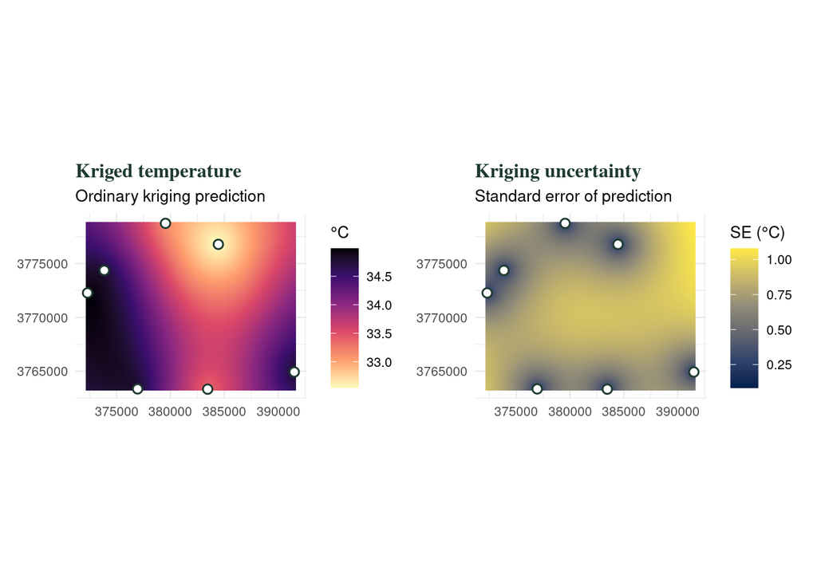

Kriged temperature surface across Los Angeles monitoring stations. Left: predicted temperature (ordinary kriging). Right: kriging standard error — higher uncertainty at the edges of the study domain (far from any monitoring station) and lower uncertainty near stations. This uncertainty surface is unique to kriging and invaluable for sensor network design: place new stations where the SE is highest.

```r
# Extract station coordinates from sp object into a plain data frame
# as.data.frame() on a SpatialPoints* stores coords in a sub-matrix;
# use coordinates() to pull them out as named columns instead.
la_pts_df <- as.data.frame(coordinates(la_utm))
names(la_pts_df) <- c("lon", "lat")

# ── Predicted temperature ─────────────────────────────────────────────────
p_pred <- ggplot(krige_df, aes(x = lon, y = lat, fill = temp_pred)) +
  geom_raster(interpolate = TRUE) +
  geom_point(data = la_pts_df,
             aes(x = lon, y = lat),
             inherit.aes = FALSE,
             shape = 21, fill = "white", colour = "#1e3a2f",
             size = 2.2, stroke = 0.8) +
  scale_fill_viridis_c(option = "magma", name = "°C", direction = -1) +
  coord_equal() +
  labs(title = "Kriged temperature", subtitle = "Ordinary kriging prediction") +
  theme_minimal(base_size = 10) +
  theme(plot.title = element_text(family = "serif", face = "bold",
                                   colour = "#1e3a2f"),
        axis.title = element_blank())

# ── Kriging standard error ────────────────────────────────────────────────
p_se <- ggplot(krige_df, aes(x = lon, y = lat, fill = temp_se)) +
  geom_raster(interpolate = TRUE) +
  geom_point(data = la_pts_df,
             aes(x = lon, y = lat),
             inherit.aes = FALSE,
             shape = 21, fill = "white", colour = "#1e3a2f",
             size = 2.2, stroke = 0.8) +
  scale_fill_viridis_c(option = "cividis", name = "SE (°C)") +
  coord_equal() +
  labs(title = "Kriging uncertainty", subtitle = "Standard error of prediction") +
  theme_minimal(base_size = 10) +
  theme(plot.title = element_text(family = "serif", face = "bold",
                                   colour = "#1e3a2f"),
        axis.title = element_blank())

p_pred + p_se
```

**📌 Kriging vs. simple interpolation methods**

You might wonder: why not just use inverse distance weighting (IDW) or a spline? Kriging has three advantages. First, it is **optimal** — it minimises mean squared prediction error given the fitted variogram. Second, it produces **uncertainty estimates** (the kriging variance), which IDW and splines do not. Third, it **respects spatial structure**: the variogram explicitly models how quickly autocorrelation decays with distance, rather than assuming a fixed decay function. The cost is complexity — you must fit and validate the variogram model. For large or irregular domains, this is always worth it.

### 10.5 Universal kriging: incorporating land-use covariates

**Ordinary kriging** (above) interpolates using spatial autocorrelation alone. **Universal kriging** (also called kriging with external drift) incorporates auxiliary variables — here, impervious surface fraction — as a deterministic trend, then kriging the residuals. This often substantially improves predictions in environmentally heterogeneous areas.

```r
# Fit a variogram on residuals from the land-use trend
vario_uk <- variogram(temp_C ~ imperv_frac, data = la_utm,
                      cutoff = 25000, width = 3000)
fit_uk   <- fit.variogram(vario_uk,
                           model = vgm(psill = 0.9, model = "Sph",
                                       range = 12000, nugget = 0.2))

# grid_pts already carries imperv_frac (added in krige-grid before gridded())
krige_uk <- krige(temp_C ~ imperv_frac,
                   locations = la_utm,
                   newdata   = grid_pts,
                   model     = fit_uk)
```

```
## [using universal kriging]
```

```r
cat("Universal kriging RMSE (cross-val approx.):",
    round(sqrt(mean(krige_uk$var1.var, na.rm = TRUE)), 3), "°C\n")
```

```
## Universal kriging RMSE (cross-val approx.): 0.502 °C
```

## 11. Reporting Spatial Analysis

### What every spatial analysis must document

1. **Data source and vintage** — where did the shapefiles and attribute data come from? Include URL, version, and download date.
2. **CRS used** — report the EPSG code for both the source CRS and the analysis CRS. State explicitly whether any reprojection was performed.
3. **Spatial join logic** — which predicate (`st_within`, `st_intersects`, etc.) and why. Note any features that failed to join.
4. **Variogram model** — for kriging: the model type (spherical, exponential, etc.), nugget, sill, range, and how the model was fit (eye-fit, REML, WLS).
5. **Prediction grid** — resolution and extent; acknowledge edge effects.
6. **Validation** — report leave-one-out cross-validation RMSE or hold-out set accuracy for kriging predictions.

### Quick-reference: common sf workflows

```r
library(sf)

# ── Reading / writing ─────────────────────────────────────────────────────
st_read("file.shp")                          # read shapefile
st_read("file.geojson")                      # read GeoJSON
st_write(sf_obj, "output.gpkg")              # write GeoPackage

# ── CRS ───────────────────────────────────────────────────────────────────
st_crs(sf_obj)                               # check CRS
st_transform(sf_obj, crs = 5070)             # reproject

# ── Geometry operations ───────────────────────────────────────────────────
st_buffer(sf_obj, dist = 1000)               # 1 km buffer (in metres if projected)
st_union(sf_obj)                             # dissolve all features into one
st_centroid(sf_obj)                          # centroid of each polygon
st_area(sf_obj)                              # area (m² if projected)
st_distance(points_a, points_b)              # pairwise distances

# ── Spatial join / filter ─────────────────────────────────────────────────
st_join(points, polygons, join = st_within)  # attach polygon attrs to points
st_filter(points, polygons)                  # keep only points inside polygons
st_intersection(layer_a, layer_b)            # geometric intersection

# ── Converting back to data frame ─────────────────────────────────────────
st_drop_geometry(sf_obj)                     # remove geometry, return data.frame
as.data.frame(sf_obj)                        # same effect
```

#### 🔑 Key Takeaways

- **Spatial data violates independence.** Nearby observations are correlated (Tobler’s First Law). Standard tests applied naively overstate precision. Use spatial statistics — or at minimum, map your data before analysing it.
- **CRS management is not optional.** Always check `st_crs()` before overlaying layers. Reproject with `st_transform()`; use equal-area projections (EPSG:5070) for area/distance calculations in the continental US.
- **Shapefiles travel in folders.** The `.shp` file alone is unreadable — you need `.dbf`, `.shx`, and `.prj` too. Prefer GeoPackage (`.gpkg`) for new work.
- **Spatial joins** link layers by location, not by a shared key column. Use `st_join()` with the appropriate predicate (`st_within`, `st_intersects`, etc.).
- **Kriging** is optimal spatial interpolation: it exploits the variogram to produce both a predicted surface and a prediction uncertainty surface. The uncertainty map is as valuable as the prediction — use it to guide sensor placement and communicate confidence to decision-makers.
- The **urban heat island** signal is recoverable from routine monitoring data: impervious surface fraction and canopy cover together explain most intra-city temperature variation after controlling for regional climate.

### What’s next?

- **Time Series** — temporal autocorrelation is the time-domain twin of spatial autocorrelation; many of the same concepts apply
- **Multiple Regression & GLMs** — spatial regression (spatial lag and spatial error models) extends OLS to handle spatial autocorrelation in residuals
- Remote Sensing module (coming soon) — raster spatial data with `terra`: land surface temperature from Landsat, NDVI, and supervised classification